# Estimating chi

Spectra of temperature gradients are located within the diss structure created in matlab when running quick_look (find them in diss.sclar_spectra.scalar_spec). They are the uncorrected frequency spectra. Function get_scalar_spectra-odas.m calculates spectra of scalar vectors (including fast temperature gradients), uses functions clean_shear_spec.m or csd_odas.m to calculate spectra. On calculation of the spectra, the temperature gradient data are detrended linearly per fft segment. Detrending is done by fitting a linear model using polyfit() in matlab, and then substracting this model from the data. In this notebook data were HP filtered (topband = 1/4 fft_length, pass_band = 1/2 fft_length), instead of detrended!

This notebook imports the spectral data saved from matlab, corrects for the frequency response of the sensor using Vachon and Lueck correction (used by Rockland in odas and by Bluteau) and tries to fit the model stated in Bluteau to the spectrum.

Data from profile 032 used for testing, dive depth was 414 m. 146 spectra were calculated.

### Reading in the data

```r
# read in data
spec <- readMat('../data/gradT_spectra_HPfilt_fftl2.mat')
diss <- readMat('../data/Diss_032_fft2.mat')
diss_fieldnames <- unlist(readMat('../data/diss_fieldnames_fft2.mat'))
```

```r
# spectrum energy values
gradT1 <- spec[[1]][[1]][,1,]
gradT2 <- spec[[1]][[1]][,2,]
```

```r
# wavenumber 2D matrix with each column for one depth segment
waven1 <- spec[[1]][[3]]

# frequency matrix
freq <- spec[[1]][[2]]
```

```r
# additional variables
mean_speed <- diss[[1]][[16]]
pressure <- diss[[1]][[18]]
eps <- diss[[1]][[1]]
eps1 <- eps[1,]
eps2 <- eps[2,]
rm(diss)
rm(spec)
```

### Correcting for frequency response

The following calculations are done exemplary for only one temperature sensor.

- expression for tau from odas library

```r
F_0 <- 25*sqrt(mean_speed)
tau_therm <- 2*pi*F_0 / sqrt(sqrt(2) - 1)   # time constant for double-pole response
tau_therm <- 1 / tau_therm
#correction:
gradT1_c <- matrix(data=NA, nrow=length(freq[,1]), ncol=length(freq[1,]))
for(index in 1:length(freq[1,])){
  gradT1_c[,index] <- gradT1[,index] * (1 + (2*pi*tau_therm[index]*freq[,index])^2)^2
}

# H_VL correction as in Bluteau
tau0 <- 4.1 / 1000
u0 <- 1
u3 <- mean_speed   # average profiling velocity
tau_vl <- tau0 * (u3/u0)^-1/2
gradT1_c_vl <- matrix(data=NA, nrow=length(freq[,1]), ncol=length(freq[1,]))
for(index in 1:length(freq[1,])){
  gradT1_c_vl[,index] <- gradT1[,index] * (1 + (2*pi*tau_vl[index]*freq[,index])^2)^2
}

# H_S correction as in Bluteau
tau_s <- 0.01 #[s]
gradT1_c_s <- matrix(data=NA, nrow=length(freq[,1]), ncol=length(freq[1,]))
for(index in 1:length(freq[1,])){
  gradT1_c_s[,index] <- gradT1[,index] * (1 + (2*pi*tau_s*freq[,index])^2)^2
}
```

#### Plot of uncorrected and corrected spectrum

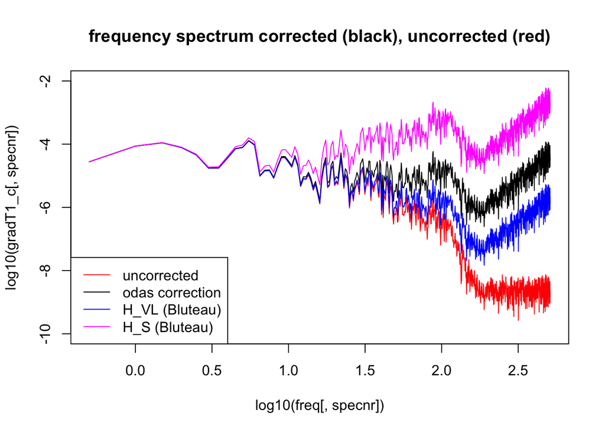

### Fit model to spectra with chi as parameter estimated with MLE

model to fit: psi_gradT(k) = C_T * chi * eps^-1/3 * k^1/3

with psi_gadT –> corrected energy spectrum,

C_T = Obukhov-Corrsin universal constant with values between 0.3 and 0.5, 0.4 recommended,

and k = wavenumber (k is here in rad/m, a conversion coefficient to convert to cpm should be added to the model?)

#### plot model for some chi values

```r
C_T <- 0.4
chi <- c(10^(-5), 10^(-7), 10^(-9))
k <- waven1[,1]
psi <- matrix(NaN, nrow=length(k), ncol=length(chi))
for(chii in 1:length(chi)){
  psi[,chii] <- C_T * chi[chii] * eps1[1]^(-1/3) * k^(1/3)
}
```

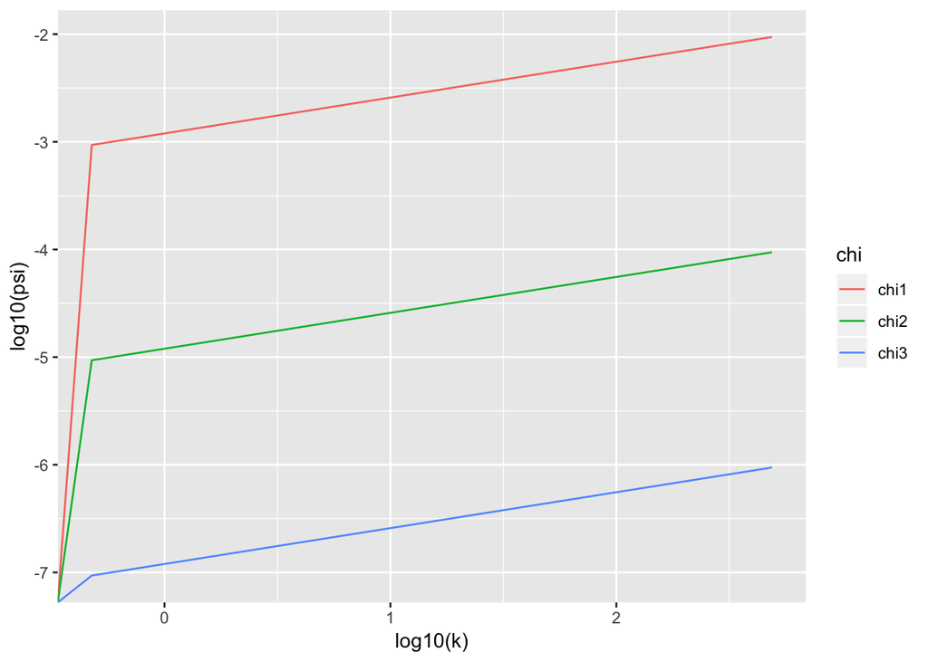

#### Convert measured spectra to wavenumber spectra

```r
P_gradT1_c <- matrix(NA, nrow = length(gradT1_c[,1]), ncol=length(gradT1_c[1,]))
for(index in 1:length(gradT1_c[,1])){
  P_gradT1_c[index,] <- gradT1_c[index,] * mean_speed
}
```

#### Test slope of inertial sub-range, i.e. range over which chi will be estimated by model

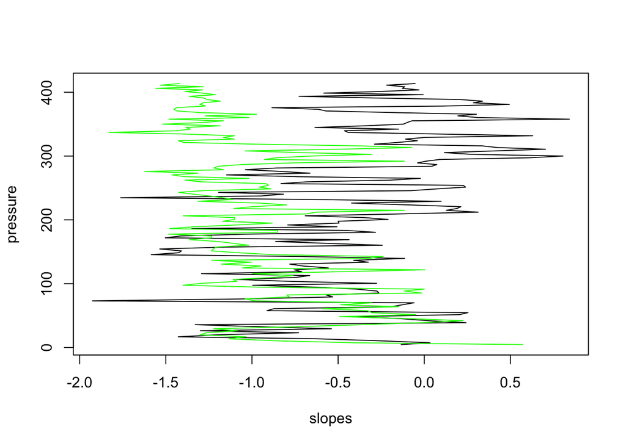

```r
slopes <- c()
for(i in 1:length(P_gradT1_c[1,])){
  segment <- i
  eta_i <- (((10^-6)^3)/eps1[i])^0.25 # Kolmogorov length scale
  K_max <- 0.1/eta_i
  K_min <- 0
  min_ind <- max(length(waven1[waven1[,segment]<=K_min, segment]),2)
  max_ind <- length(waven1[waven1[,segment]<=K_max,segment]) # index for subsetting model values
  y <- P_gradT1_c[min_ind:max_ind,segment]   # corrected wavenumber temp-gradient spectrum --> P_gradT1_c
  x <- waven1[min_ind:max_ind,segment]
  # fit a linear model to check
  linearmod <- lm(log10(y) ~ log10(x))
  slopes[i] <- linearmod$coefficients[2]
}

plot(slopes, pressure, type='l')
lines(log10(eps[1,])+8, pressure, col='green')
```

##### Choose spectrum to run model on

```r
specnr <- 30 # 70 is a good one, 100 too, 16 too
segment <- specnr
```

##### find highest value for k to include in fit using the criterium correction H(k) <= 3

```r
# calculate correction factor
f <- freq[,segment]
tau0 <- 4.1 * 10^-3
speed0 <- 1
tau <- tau0 * (mean_speed[segment,]/speed0)^(-0.5)
Hf <- (1 + (2 * pi * tau *f)^2)^(2)
# find index where Hf exceeds 3
ind <- length(Hf[Hf <= 3])
# find K at ind
K_max = waven1[ind,segment]

# k must never be higher than 0.1 * eta^-1 (eta = Kolmogorov length scale)
eta <- (((10^-6)^3)/mean(eps1[segment],eps2[segment]))^0.25 # Kolmogorov length scale
K_max <- min(0.1/eta,K_max)
```

##### define x and y for model, only use spectrum for wavenumbers < Kmax and > Kmin

```r
steps <- 0 #? was error, don't know what to choose
#eps1 <- eps[1,]
# K_min needs to be checked after fitting, default value = 0
K_min <- waven1[2*steps+2,segment] #0
min_ind <- max(length(waven1[waven1[,segment]<=K_min, segment]),2)
max_ind <- length(waven1[waven1[,segment]<=K_max,segment]) # index for subsetting model values
y <- P_gradT1_c[min_ind:max_ind,segment]   # corrected wavenumber temp-gradient spectrum --> P_gradT1_c
x <- waven1[min_ind:max_ind,segment]
```

##### Definition of likelihood function

```r
#likelihood function definition
LL <- function(chi) {
  # Find residuals
  R = y - C_T * chi * mean(eps1[segment],eps2[segment])^(-1/3) * x^(1/3)
  # Calculate the likelihood for the residuals
  R = suppressWarnings(dnorm(R, log = TRUE))
  # Sum the log likelihoods for all of the data points
  -sum(R)
}

#model fit
fit <- suppressWarnings(mle(LL, start = list( chi=10^(-7))
                            ,nobs = length(y),  method='L-BFGS-B'))
```

##### Results of model fit - chi = 4.001948510^{-8}

```
## Maximum likelihood estimation
##
## Call:
## mle(minuslogl = LL, start = list(chi = 10^(-7)), method = "L-BFGS-B",
##     nobs = length(y))
##
## Coefficients:
##         Estimate   Std. Error
## chi 4.001949e-08 0.0001910522
##
## -2 log L: 80.86659
```

##### calculate model with fitted chi for plotting

```r
spec_model <-  C_T * fit@coef[1] * mean(eps1[segment],eps2[segment])^(-1/3) * x^(1/3)
```

##### check for lower K condition using MAD on observed and modelled spec

```r
phi <- y
psi <- spec_model
steps <- 6  # 0.5-0.7 of a decade long?
nr_steps <- floor(length(phi)/steps)
modulo <- length(phi) %% steps
if(modulo >= 4){
  nr_steps <- nr_steps + 1
}

# calculate MAD for steps of 6 values for the spectrum
MAD <- c()
crit <- c()
for(i in 1:nr_steps){
    n_st <- (i-1) * steps + 1
    if(i == nr_steps){
      if(modulo >= 4){
        n_en <- n_st + modulo - 1
      }else{
        n_en <- n_st + steps - 1 + modulo
      }
    }else{
      n_en <- n_st + steps - 1
    }
    phi_n = phi[n_st:n_en]
    psi_n = psi[n_st:n_en]
    MAD[i] <-  1/(length(phi_n)) * sum(abs(phi_n/psi_n - mean(phi_n/psi_n)))

    # check whether MAD fits criteria, crit = 0 (bad), 1 (good)
    dof <- length(phi_n) - 1
    crit[i] <- ifelse(MAD[i] < 2 * (2/dof)^0.5, 1, 0)

} # end for loop

#If all subsets of the spectrum yielded a MAD>2(2/d)^1/2 (d = degrees of freedom --> n-1 ?) (Ruddick et al. 2000), then the spectrum is completely discarded. Otherwise, the final wavenumber range used to obtain xF starts at the lowest wavenumber at which MAD<2(2/d)^1/2

# to decide whether to through away spectrum
if(sum(crit) == 0){
  print('MADs does not fulfills criteria, spectrum should be discarded')
}else if(sum(crit) > 0 & sum(crit) < length(crit)){
  print('at least one MAD value outside allowed range, choose minimum K')
}else if(sum(crit) == length(crit)){
  print('all MADs fulfill criteria, good spectrum')
  print(paste('specnr ', specnr, ': estimated Chi = ', signif(fit@coef,3), ', Eps = ', signif(mean(eps1[segment],eps2[segment]),3), sep = ''))
  print(paste('logLik = ', signif(logLik(fit),3), ', AIC = ', signif(AIC(fit),3), sep=''))
  print(paste('K_min = ', signif(K_min,3), ', K_max = ', signif(K_max,3), sep=''))
}
```

```
## [1] "at least one MAD value outside allowed range, choose minimum K"
```

```r
# check smallest
#indexcr <- steps #(length(crit[crit==0]) + 1 ) * steps
#K_min <- waven1[indexcr,segment]

# fit a linear model to check
linearmod <- lm(log10(y) ~ log10(x))
print(paste('slope of linear model:', signif(linearmod$coefficients[2],3)))
```

```
## [1] "slope of linear model: -0.627"
```

##### plot data and model

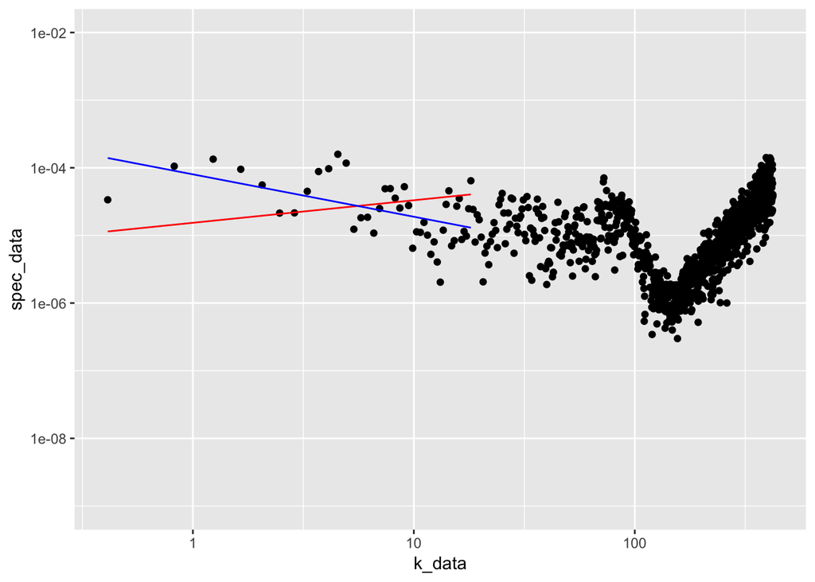

```r
pl_data <- data.frame(k_data=waven1[-1,segment], spec_data=P_gradT1_c[-1,segment])
pl_model <- data.frame(k_model = x, spec_model = spec_model)
pl_linm <- data.frame(linm_x = x, linm_y = 10^(linearmod$coefficients[2]*log10(x)+linearmod$coefficients[1]))
ggplot() +
  geom_point(data=pl_data, aes(x=k_data, y = spec_data)) +
  geom_line(data=pl_model, aes(x=k_model, y=spec_model), color='red') +
  scale_y_continuous(trans='log10', limits=c(10^-9,10^-2)) +
  scale_x_continuous(trans='log10') + #, limits=c(x[1],K_max)) +
  geom_line(data = pl_linm, aes(x=linm_x, y = linm_y), color = 'blue')
```